# Predicting NYC Taxi Tips

Bin Kim

8/28/2020

```r
taxi_train = read_csv("week2.csv")
taxi_test = read_csv("week4.csv")
taxi_train %>% summary()
```

```
##     VendorID     tpep_pickup_datetime          tpep_dropoff_datetime
##  Min.   :1.000   Min.   :2016-01-08 00:00:00   Min.   :2016-01-08 00:01:23
##  1st Qu.:1.000   1st Qu.:2016-01-09 18:02:05   1st Qu.:2016-01-09 18:16:14
##  Median :2.000   Median :2016-01-11 15:19:10   Median :2016-01-11 15:33:52
##  Mean   :1.532   Mean   :2016-01-11 14:11:04   Mean   :2016-01-11 14:25:25
##  3rd Qu.:2.000   3rd Qu.:2016-01-13 11:35:15   3rd Qu.:2016-01-13 11:50:25
##  Max.   :2.000   Max.   :2016-01-14 23:59:59   Max.   :2016-01-15 23:39:18
##  passenger_count trip_distance     pickup_longitude  pickup_latitude
##  Min.   :0.000   Min.   :  0.000   Min.   :-121.93   Min.   : 0.00
##  1st Qu.:1.000   1st Qu.:  1.000   1st Qu.: -73.99   1st Qu.:40.74
##  Median :1.000   Median :  1.630   Median : -73.98   Median :40.75
##  Mean   :1.659   Mean   :  2.809   Mean   : -72.84   Mean   :40.13
##  3rd Qu.:2.000   3rd Qu.:  3.000   3rd Qu.: -73.97   3rd Qu.:40.77
##  Max.   :9.000   Max.   :502.200   Max.   :   0.00   Max.   :46.31
##    RatecodeID     store_and_fwd_flag dropoff_longitude dropoff_latitude
##  Min.   : 1.000   Length:2651287     Min.   :-121.93   Min.   : 0.00
##  1st Qu.: 1.000   Class :character   1st Qu.: -73.99   1st Qu.:40.74
##  Median : 1.000   Mode  :character   Median : -73.98   Median :40.75
##  Mean   : 1.036                      Mean   : -72.91   Mean   :40.17
##  3rd Qu.: 1.000                      3rd Qu.: -73.96   3rd Qu.:40.77
##  Max.   :99.000                      Max.   :   0.00   Max.   :52.75
##   payment_type    fare_amount          extra             mta_tax
##  Min.   :1.000   Min.   :-957.60   Min.   :-35.6400   Min.   :-0.5000
##  1st Qu.:1.000   1st Qu.:   6.50   1st Qu.:  0.0000   1st Qu.: 0.5000
##  Median :1.000   Median :   9.00   Median :  0.0000   Median : 0.5000
##  Mean   :1.337   Mean   :  12.06   Mean   :  0.3235   Mean   : 0.4978
##  3rd Qu.:2.000   3rd Qu.:  13.50   3rd Qu.:  0.5000   3rd Qu.: 0.5000
##  Max.   :4.000   Max.   :3039.00   Max.   :  4.1000   Max.   :36.4400
##    tip_amount        tolls_amount      improvement_surcharge  total_amount
##  Min.   :-220.800   Min.   :-12.5000   Min.   :-0.3000       Min.   :-958.40
##  1st Qu.:   0.000   1st Qu.:  0.0000   1st Qu.: 0.3000       1st Qu.:   8.30
##  Median :   1.320   Median :  0.0000   Median : 0.3000       Median :  11.30
##  Mean   :   1.728   Mean   :  0.2746   Mean   : 0.2998       Mean   :  15.18
##  3rd Qu.:   2.260   3rd Qu.:  0.0000   3rd Qu.: 0.3000       3rd Qu.:  16.56
##  Max.   : 900.000   Max.   :811.0000   Max.   : 0.3000       Max.   :3045.34
```

# Handling Negative Values

`summary()` indicates there are negative values in monetary variables.

```r
taxi_train %>%
        filter(total_amount < 0) %>%
        select(fare_amount, extra, mta_tax, tip_amount, tolls_amount, improvement_surcharge, total_amount) %>%
        head(20)
```

```
## # A tibble: 20 x 7
##    fare_amount extra mta_tax tip_amount tolls_amount improvement_surcharge
##          <dbl> <dbl>   <dbl>      <dbl>        <dbl>                 <dbl>
##  1       -11.1     0     0        -2.85            0                  -0.3
##  2        -3       0    -0.5       0               0                  -0.3
##  3        -4.5     0    -0.5       0               0                  -0.3
##  4        -4.5     0    -0.5       0               0                  -0.3
##  5        -4       0    -0.5       0               0                  -0.3
##  6        -2.5     0    -0.5       0               0                  -0.3
##  7        -4       0    -0.5       0               0                  -0.3
##  8        -3       0    -0.5       0               0                  -0.3
##  9        -2.5     0    -0.5       0               0                  -0.3
## 10        -3.5     0    -0.5       0               0                  -0.3
## 11        -4.5     0    -0.5       0               0                  -0.3
## 12        -3       0    -0.5       0               0                  -0.3
```

[output cut: 30 more lines]

Negative total amounts are still the sum of their monetary variables. Looks like most of these values can be fixed by simply turning them back into absolute values.

```r
taxi_train <- taxi_train %>% mutate(
    fare_amount = abs(fare_amount),
    extra = abs(extra),
    mta_tax = abs(mta_tax),
    tip_amount = abs(tip_amount),
    tolls_amount = abs(tolls_amount),
    improvement_surcharge = abs(improvement_surcharge),
    total_amount = abs(total_amount)
)

taxi_test <- taxi_test %>% mutate(
    fare_amount = abs(fare_amount),
    extra = abs(extra),
    mta_tax = abs(mta_tax),
    tip_amount = abs(tip_amount),
    tolls_amount = abs(tolls_amount),
    improvement_surcharge = abs(improvement_surcharge),
    total_amount = abs(total_amount)
)
```

# Variable Examination

## Variable Transformation

```r
head(taxi_train$tpep_pickup_datetime)
```

```
## [1] "2016-01-08 21:29:06 UTC" "2016-01-08 21:51:37 UTC"
## [3] "2016-01-08 22:19:28 UTC" "2016-01-08 22:31:32 UTC"
## [5] "2016-01-09 00:35:25 UTC" "2016-01-09 00:48:28 UTC"
```

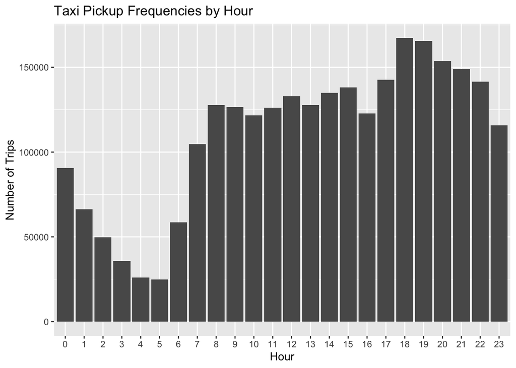

```r
taxi_train %>%
    ggplot(aes(x=factor(hour(tpep_pickup_datetime)))) + geom_bar() + labs(title = "Taxi Pickup Frequencies by Hour", x = "Hour", y = "Number of Trips")
```

The data indicates that the recorded times are in UTC format, but this doesn't seem to be true. Times seem to be already set in EST.

Changing variable names to be meaningful, and creating useful variables...

```r
# train data, week 2
taxi_train <- taxi_train %>%
    mutate(dropoff_datetime = tpep_dropoff_datetime,
           pickup_datetime = tpep_pickup_datetime,
           dow = wday(pickup_datetime, label=TRUE, abbr=TRUE, week_start = 1),
           dow = as.character(dow),
           dow = factor(dow, ordered = FALSE, levels = c("Mon", "Tue", "Wed", "Thu", "Fri", "Sat", "Sun")),
           hour_trip_start = factor(hour(pickup_datetime)),
           trip_duration = as.numeric(difftime(dropoff_datetime, pickup_datetime, units = "mins")),
           payment_type_label = fct_recode(factor(payment_type),
                                           "Credit Card" = "1",
                                           "Cash" = "2",
                                           "No Charge" = "3",
                                           "Other"= "4")) %>%
    select(-c(payment_type, tpep_pickup_datetime, tpep_dropoff_datetime))

# test data, week 4
taxi_test <- taxi_test %>%
    mutate(dropoff_datetime = tpep_dropoff_datetime,
           pickup_datetime = tpep_pickup_datetime,
           dow = wday(pickup_datetime, label=TRUE, abbr=TRUE, week_start = 1),
           dow = as.character(dow),
           dow = factor(dow, ordered = FALSE, levels = c("Mon", "Tue", "Wed", "Thu", "Fri", "Sat", "Sun")),
           hour_trip_start = factor(hour(pickup_datetime)),
           trip_duration = as.numeric(difftime(dropoff_datetime, pickup_datetime, units = "mins")),
           payment_type_label = fct_recode(factor(payment_type),
                                           "Credit Card" = "1",
                                           "Cash" = "2",
                                           "No Charge" = "3",
                                           "Other"= "4")) %>%
    select(-c(payment_type, tpep_pickup_datetime, tpep_dropoff_datetime))
```

## total_amount

We're not going to be using this variable in our model because we know it contains direct information about the tip amount. We'll just use it as a error checker and select rows where their total amount equals the sum of all the monetary variables.

```r
taxi_train <- taxi_train %>%
    filter(total_amount == fare_amount + extra + mta_tax + improvement_surcharge + tip_amount + tolls_amount)

taxi_test <- taxi_test %>%
    filter(total_amount == fare_amount + extra + mta_tax + improvement_surcharge + tip_amount + tolls_amount)
```

## payment_type

```r
unique(taxi_train$payment_type_label)
```

```
## [1] Credit Card Cash        Other       No Charge
## Levels: Credit Card Cash No Charge Other
```

Only 4 out of 6 payments types in the dataset: `Unknown`, and `Voided trip` are not present.

Since it doesn't make sense to tip in a no charge trip, they will be excluded from our dataset.

```r
taxi_train <- taxi_train %>%
    filter(payment_type_label %in% c("Credit Card", "Cash", "Other"))
taxi_test <- taxi_test %>%
    filter(payment_type_label %in% c("Credit Card", "Cash", "Other"))
```

We already know that cash tips aren't included in the data. Is it still meaningful to keep trips paid with cash or 'other'?

```r
taxi_train %>%
    group_by(payment_type_label) %>%
    summarise(zero_tips = sum(tip_amount == 0), nrow = n(), ratio = zero_tips/nrow)
```

```
## # A tibble: 3 x 4
##   payment_type_label zero_tips    nrow  ratio
##   <fct>                  <int>   <int>  <dbl>
## 1 Credit Card            55209 1450100 0.0381
## 2 Cash                  848742  848754 1.00
## 3 Other                   2981    2989 0.997
```

For cash and other trips, just short of 100% of them were given zero tips. It should be safe to remove them for our purpose.

```r
taxi_train <- taxi_train %>%
    filter(payment_type_label == "Credit Card") %>%
    select(-payment_type_label) # variable not needed anymore

taxi_test <- taxi_test %>%
    filter(payment_type_label == "Credit Card") %>%
    select(-payment_type_label) # variable not needed anymore
```

## hour_trip_start

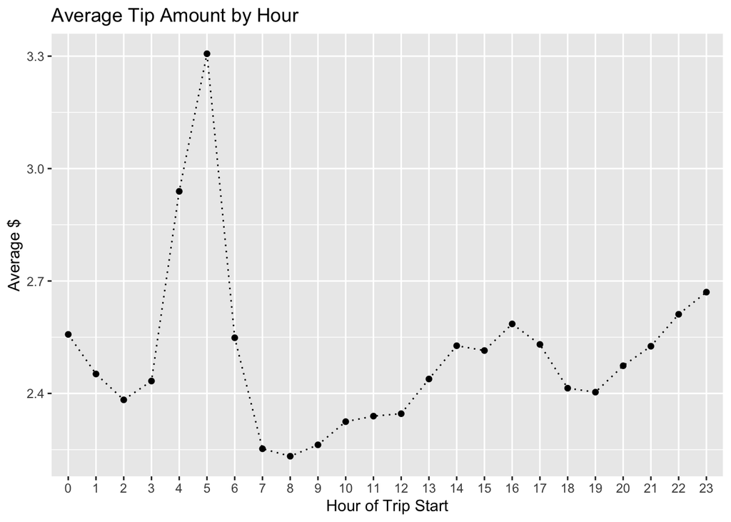

```r
taxi_train %>% group_by(hour_trip_start) %>%
    summarise(tip_mean = mean(tip_amount)) %>%
    ggplot(aes(x=hour_trip_start, y=tip_mean)) + geom_point() + geom_line(aes(group = 1), linetype="dotted") + labs(title = "Average Tip Amount by Hour", y = "Average $", x = "Hour of Trip Start")
```

Trips between 4 ~ 6 am have notably higher average tip amount than the rest. Creating a categorical varaible indicating whether a trip started between 4 ~ 6 am.

```r
taxi_train <- taxi_train %>%
    mutate(trip_4_6_am = ifelse(hour_trip_start %in% c(4,5), "Yes", "No")) %>%
    select(-hour_trip_start)

taxi_test <- taxi_test %>%
    mutate(trip_4_6_am = ifelse(hour_trip_start %in% c(4,5), "Yes", "No")) %>%
    select(-hour_trip_start)
```

*p.s. I couldn't get the interaction model to work unless I reduced the factors in this variable, so this step was rather necessary...*

## dow

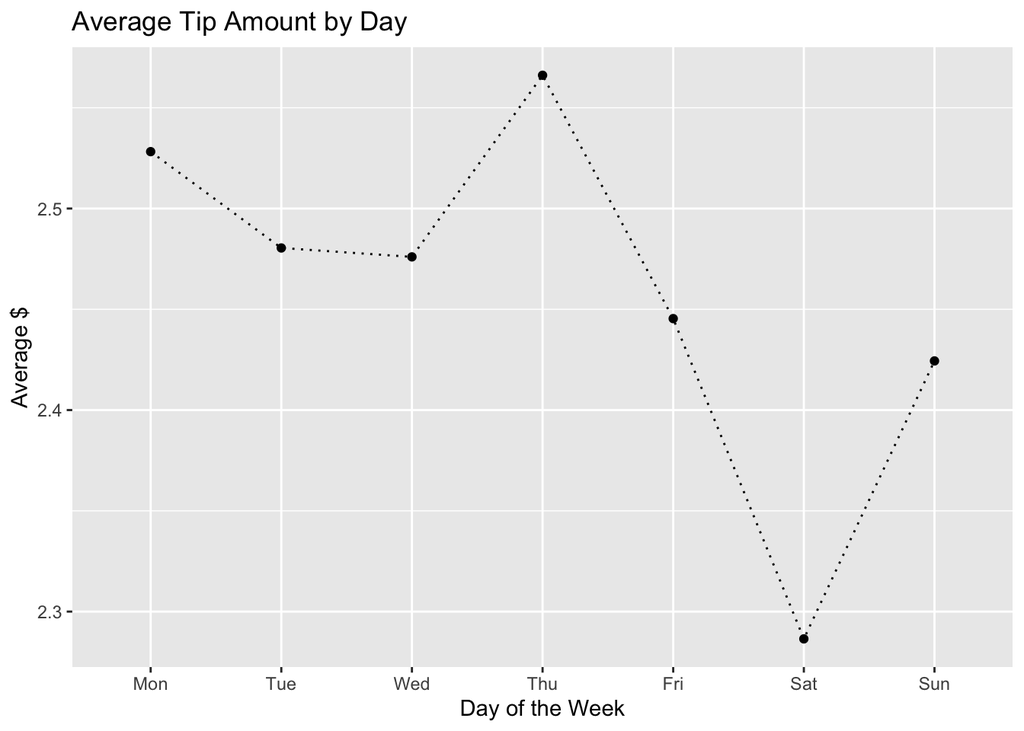

```r
taxi_train %>% group_by(dow) %>%
    summarise(tip_mean = mean(tip_amount)) %>%
    ggplot(aes(x=dow, y=tip_mean)) + geom_point() + geom_line(aes(group = 1), linetype="dotted") + labs(title = "Average Tip Amount by Day", x = "Day of the Week", y = "Average $")
```

There's difference less than $0.3 between thursday (max tip amount) and saturday (min tip amount), which is not much. Saturday trips seem to might have significantly less tips than the rest.

## fare_amount

```r
# How many trips have fare amount $0?
taxi_train %>% filter(fare_amount == 0) %>% nrow()
```

```
## [1] 108
```

```r
taxi_train %>% filter(fare_amount == 0) %>% select(fare_amount, extra, mta_tax, tip_amount, tolls_amount, improvement_surcharge, total_amount) %>% head(20)
```

```
## # A tibble: 20 x 7
##    fare_amount extra mta_tax tip_amount tolls_amount improvement_surcharge
##          <dbl> <dbl>   <dbl>      <dbl>        <dbl>                 <dbl>
##  1           0     0       0        0           0                      0.3
##  2           0     0       0       14.2        70.5                    0.3
##  3           0     0       0        9.7         0                      0.3
##  4           0     0       0        0           0                      0.3
##  5           0     0       0        0           0                      0.3
##  6           0     0       0        0          12.5                    0.3
##  7           0     0       0      100           0                      0.3
##  8           0     0       0       12           0                      0.3
##  9           0     0       0        2.7        10.5                    0.3
## 10           0     0       0      160           6.79                   0.3
## 11           0     0       0       70          10.5                    0.3
## 12           0     0       0       60          10.5                    0.3
```

[output cut: 30 more lines]

Some values with fare amount = $0 seem to have its true value of fare amount in the tolls amount column. Creating new correct variable to represent the true fare amount.

```r
taxi_train <- taxi_train %>% mutate(fare_amount_correct = ifelse(fare_amount == 0, tolls_amount, fare_amount),
               tolls_amount_correct = ifelse(fare_amount == 0, fare_amount, tolls_amount))

taxi_test <- taxi_test %>% mutate(fare_amount_correct = ifelse(fare_amount == 0, tolls_amount, fare_amount),
               tolls_amount_correct = ifelse(fare_amount == 0, fare_amount, tolls_amount))

# check again
taxi_train %>% filter(fare_amount_correct == 0)  %>% select(fare_amount_correct, extra, mta_tax, tip_amount, tolls_amount, improvement_surcharge, total_amount)
```

```
## # A tibble: 88 x 7
##    fare_amount_correct extra mta_tax tip_amount tolls_amount
##                  <dbl> <dbl>   <dbl>      <dbl>        <dbl>
##  1                   0     0       0        0              0
##  2                   0     0       0        9.7            0
##  3                   0     0       0        0              0
##  4                   0     0       0        0              0
##  5                   0     0       0      100              0
##  6                   0     0       0       12              0
##  7                   0     0       0        6              0
##  8                   0     0       0       27              0
##  9                   0     0       0        0              0
## 10                   0     0       0       59              0
##    improvement_surcharge total_amount
##                    <dbl>        <dbl>
##  1                   0.3          0.3
##  2                   0.3         10
##  3                   0.3          0.3
##  4                   0.3          0.3
##  5                   0.3        100.
##  6                   0.3         12.3
##  7                   0.3          6.3
##  8                   0.3         27.3
##  9                   0.3          0.3
## 10                   0.3         59.3
## # … with 78 more rows
```

```r
# check tip_amount
taxi_train %>% filter(fare_amount_correct == 0, tip_amount > 0) %>% select(fare_amount_correct, extra, mta_tax, tip_amount, tolls_amount, improvement_surcharge, total_amount)
```

```
## # A tibble: 35 x 7
##    fare_amount_correct extra mta_tax tip_amount tolls_amount
##                  <dbl> <dbl>   <dbl>      <dbl>        <dbl>
##  1                   0     0       0        9.7            0
##  2                   0     0       0      100              0
##  3                   0     0       0       12              0
##  4                   0     0       0        6              0
##  5                   0     0       0       27              0
##  6                   0     0       0       59              0
##  7                   0     0       0      110              0
##  8                   0     0       0       29.7            0
##  9                   0     0       0      184              0
## 10                   0     0       0       40              0
##    improvement_surcharge total_amount
##                    <dbl>        <dbl>
##  1                   0.3         10
##  2                   0.3        100.
##  3                   0.3         12.3
##  4                   0.3          6.3
##  5                   0.3         27.3
##  6                   0.3         59.3
##  7                   0.3        110.
##  8                   0.3         30
##  9                   0.3        184.
## 10                   0.3         40.3
## # … with 25 more rows
```

There are still very few trips where their true fare amount is recorded in the tip amount column. Let's be resourceful and fix and use those values.

```r
taxi_train <- taxi_train %>% mutate(
    fare_amount_correct2 = ifelse(fare_amount_correct == 0 & tip_amount > 0, tip_amount, fare_amount_correct),
    tip_amount_correct = ifelse(fare_amount_correct == 0 & tip_amount > 0, fare_amount_correct, tip_amount))


taxi_test <- taxi_test %>% mutate(
    fare_amount_correct2 = ifelse(fare_amount_correct == 0 & tip_amount > 0, tip_amount, fare_amount_correct),
    tip_amount_correct = ifelse(fare_amount_correct == 0 & tip_amount > 0, fare_amount_correct, tip_amount))

# any more values with fare amount = $0?
taxi_train %>% filter(fare_amount_correct2 == 0 & (tip_amount_correct > 0 | tolls_amount_correct > 0))
```

```
## # A tibble: 0 x 25
## # … with 25 variables: VendorID <dbl>, passenger_count <dbl>,
## #   trip_distance <dbl>, pickup_longitude <dbl>, pickup_latitude <dbl>,
## #   RatecodeID <dbl>, store_and_fwd_flag <chr>, dropoff_longitude <dbl>,
## #   dropoff_latitude <dbl>, fare_amount <dbl>, extra <dbl>, mta_tax <dbl>,
## #   tip_amount <dbl>, tolls_amount <dbl>, improvement_surcharge <dbl>,
## #   total_amount <dbl>, dropoff_datetime <dttm>, pickup_datetime <dttm>,
## #   dow <fct>, trip_duration <dbl>, trip_4_6_am <chr>,
## #   fare_amount_correct <dbl>, tolls_amount_correct <dbl>,
## #   fare_amount_correct2 <dbl>, tip_amount_correct <dbl>
```

```r
# Removing incorrect columns and renaming new corrected columns
taxi_train <- taxi_train %>%
    select(-c(tip_amount, tolls_amount, fare_amount, fare_amount_correct)) %>%
    rename(fare_amount = fare_amount_correct2, tip_amount = tip_amount_correct, tolls_amount = tolls_amount_correct)
taxi_test <- taxi_test %>%
    select(-c(tip_amount, tolls_amount, fare_amount, fare_amount_correct)) %>%
    rename(fare_amount = fare_amount_correct2, tip_amount = tip_amount_correct, tolls_amount = tolls_amount_correct)
```

NYC's taxi website states that trips initially charge $2.50 for base fare. We'll subset the dataset accordingly.

https://www1.nyc.gov/site/tlc/passengers/taxi-fare.page

https://en.wikipedia.org/wiki/Taxicabs_of_New_York_City (Above pricing is in effect since 2012.)

```r
taxi_train <- taxi_train %>%
    filter(fare_amount >= 2.5)
taxi_test <- taxi_test %>%
    filter(fare_amount >= 2.5)
```

## VendorID

```r
# Number of trips by VendorID
table(taxi_train$VendorID)
```

```
##
##      1      2
## 665245 784784
```

```r
# Unique values within variable
unique(taxi_train$VendorID, na.rm=FALSE)
```

```
## [1] 2 1
```

```r
quantile = rep(c("0%", "25%", "50%", "75%", "100%"), 2)

# Comparing similarity
## Comparing quantiles
taxi_train %>% group_by(VendorID) %>%
    summarise(quantile(tip_amount)) %>%
    bind_cols("quantile" = quantile)
```

```
## # A tibble: 10 x 3
## # Groups:   VendorID [2]
##    VendorID `quantile(tip_amount)` quantile
##       <dbl>                  <dbl> <chr>
##  1        1                   0    0%
##  2        1                   1.25 25%
##  3        1                   1.85 50%
##  4        1                   2.75 75%
##  5        1                 900    100%
##  6        2                   0    0%
##  7        2                   1.26 25%
##  8        2                   1.82 50%
##  9        2                   2.94 75%
## 10        2                 254.   100%
```

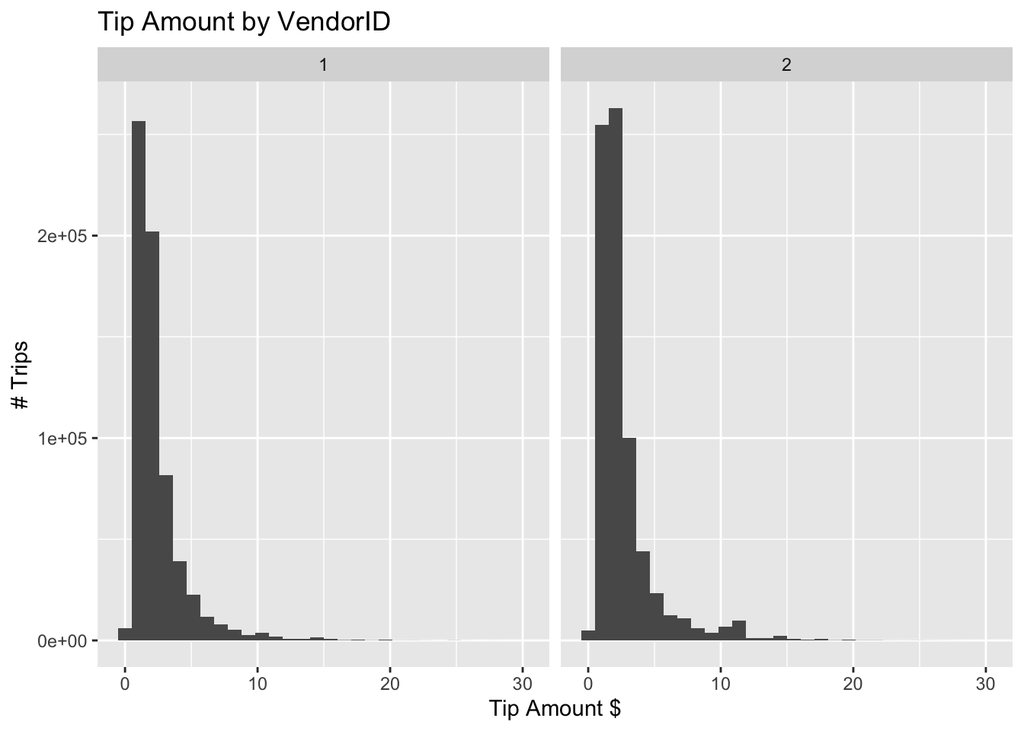

```r
## Comparing Distribution
taxi_train %>% filter(tip_amount > 0 & tip_amount < 30) %>%
    ggplot(aes(x=tip_amount)) + geom_histogram() + facet_wrap(VendorID ~ .) + labs(title = "Tip Amount by VendorID", x = "Tip Amount $", y = "# Trips")
```

Not much seems special about this variable. The two vendors each share about half of the taxis, their inner quantile values are very similar, and their distribution seem almost identical. It seems unlikely that this variable would be of any use for our goal of prediction, hence will be removed.

```r
taxi_train <- taxi_train %>%
    select(-VendorID)
taxi_test <- taxi_test %>%
    select(-VendorID)
```

## RatecodeID

```r
# Removing non-specified RatecodeID
taxi_train <- taxi_train %>%
    filter(RatecodeID %in% c(1,2,3,4,5,6))
taxi_test <- taxi_test %>%
    filter(RatecodeID %in% c(1,2,3,4,5,6))

# Renaming RatecodeID
taxi_train <- taxi_train %>% mutate(
    RatecodeID_label = fct_recode(factor(RatecodeID),
                                  "Standard_Rate" = "1",
                                  "JFK" = "2",
                                  "Newark" = "3",
                                  "Nassau_Westchester" = "4",
                                  "Neogitated_Fare" = "5",
                                  "Group_Ride" = "6")
)

taxi_test <- taxi_test %>% mutate(
    RatecodeID_label = fct_recode(factor(RatecodeID),
                                  "Standard_Rate" = "1",
                                  "JFK" = "2",
                                  "Newark" = "3",
                                  "Nassau_Westchester" = "4",
                                  "Neogitated_Fare" = "5",
                                  "Group_Ride" = "6")
)

taxi_train = select(taxi_train, -RatecodeID)
taxi_test = select(taxi_test, -RatecodeID)

# Unique ratecodes
unique(taxi_train$RatecodeID_label, na.rm=FALSE)
```

```
## [1] Standard_Rate      JFK                Nassau_Westchester Neogitated_Fare
## [5] Newark             Group_Ride
## 6 Levels: Standard_Rate JFK Newark Nassau_Westchester ... Group_Ride
```

```r
# Number of trips by ratecode
taxi_train %>% group_by(RatecodeID_label) %>%
    summarise(n())
```

```
## # A tibble: 6 x 2
##   RatecodeID_label     `n()`
##   <fct>                <int>
## 1 Standard_Rate      1416454
## 2 JFK                  26015
## 3 Newark                2194
## 4 Nassau_Westchester     524
## 5 Neogitated_Fare       4802
## 6 Group_Ride               1
```

Only one group ride left in the dataset. It's likely that test dataset will contain very few of them as well, hence it will be removed for the purposes of model optimisation.

```r
taxi_train <- taxi_train %>%
    filter(RatecodeID_label != "Group_Ride") %>%
    mutate(RatecodeID_label = factor(RatecodeID_label))
taxi_test <- taxi_test %>%
    filter(RatecodeID_label != "Group_Ride") %>%
    mutate(RatecodeID_label = factor(RatecodeID_label))
```

Almost all of the trips are standard rated. JFK rate trips come second consisting about 2% of the data set, and they are the $52 flat rate trips.

```r
# JFK trips
## Train data
taxi_train %>%
    filter(RatecodeID_label == "JFK") %>%
    group_by(fare_amount) %>%
    summarise(Frequency = n()) %>%
    arrange(desc(Frequency))
```

```
## # A tibble: 8 x 2
##   fare_amount Frequency
##         <dbl>     <int>
## 1        52       26008
## 2         6           1
## 3        16           1
## 4        29.5         1
## 5        29.8         1
## 6        34           1
## 7        45.3         1
## 8       150           1
```

```r
## Test data
taxi_test %>%
    filter(RatecodeID_label == "JFK") %>%
    group_by(fare_amount) %>%
    summarise(Frequency = n()) %>%
    arrange(desc(Frequency))
```

```
## # A tibble: 9 x 2
##   fare_amount Frequency
##         <dbl>     <int>
## 1        52       22687
## 2        11           1
## 3        12.5         1
## 4        12.8         1
## 5        17.3         1
## 6        24.8         1
## 7        26.3         1
## 8        31.3         1
## 9        69.5         1
```

```r
# Removing JFK trips with fare amount not eqaul to $52
taxi_train <- taxi_train %>%
    filter(RatecodeID_label != "JFK" | fare_amount == 52)
taxi_test <- taxi_test %>%
    filter(RatecodeID_label != "JFK" | fare_amount == 52)
```

## trip_duration

First, we'll need to remove trips with duration <= 0. In fact, we'll regard the trips that lasted under 30 seconds as errors.

```r
taxi_train <- taxi_train %>%
    filter(trip_duration >= 0.5)
taxi_test <- taxi_test %>%
    filter(trip_duration >= 0.5)
```

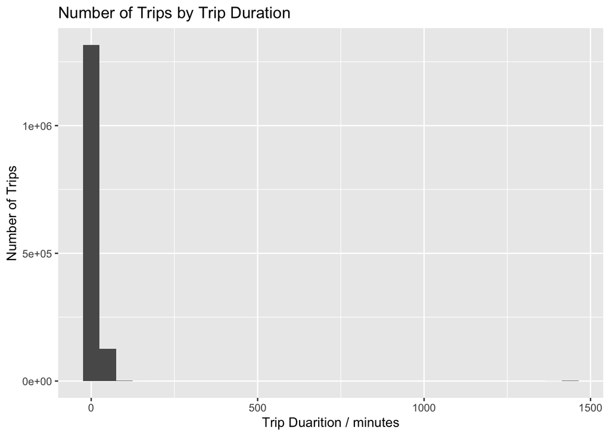

```r
taxi_train %>% ggplot(aes(x=trip_duration)) + geom_histogram() + labs(title = "Number of Trips by Trip Duration", x = "Trip Duarition / minutes", y = "Number of Trips")
```

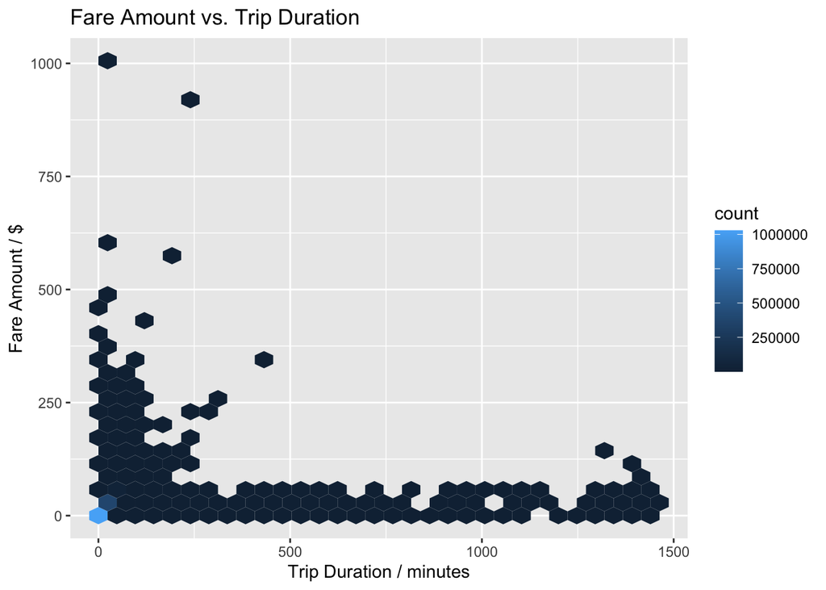

```r
taxi_train %>% ggplot(aes(x=trip_duration, y=fare_amount)) + geom_hex() + labs(title = "Fare Amount vs. Trip Duration", x="Trip Duration / minutes", y = "Fare Amount / $")
```

some trips within the dataset went for over 20 hours which is absurd. Some trips clearly don't match its fare amount given their duration, so we'll filter the dataset so that trips longer than an hour must have been charged $0.5 per minute (based on fare rate '50c per 1/5th mile or 60 seconds').

Some trips are charged way too much with respect to their trip duration. We'll pose another limit on the dataset. The highest posted speed limit in New York is 65 mph (https://en.wikipedia.org/wiki/Speed_limits_in_the_United_States_by_jurisdiction#). Therefore, at maximum, taxis can drive $\frac{65}{60}$ miles per minute and earn $\frac{65}{60} \times 2.5$ ($.50 per 1/5th mile) per minute. Trips with fare amount greater than $60 will be affected by this filtering.

*p.s. I had to use hex plot instead of points because it would take too long to generate the plot.*

```r
# Data filtering
taxi_train <- taxi_train %>%
    filter(trip_duration < 60 | fare_amount > .5 * trip_duration) %>% # absurdly long trips
    filter(fare_amount < 60 | fare_amount < (65/60) * 2.5 * trip_duration + 2.5) # absurdly expensive trips

taxi_test <- taxi_test %>%
    filter(trip_duration < 60 | fare_amount > .5 * trip_duration) %>% # absurdly long trips
    filter(fare_amount < 60 | fare_amount < (65/60) * 2.5 * trip_duration + 2.5) # absurdly expensive trips
```

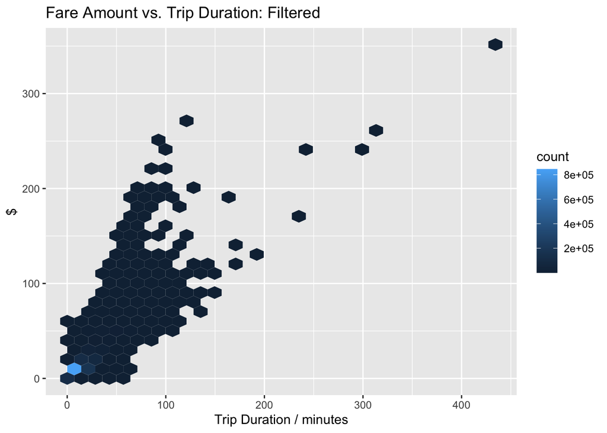

```r
taxi_train %>% ggplot(aes(x=trip_duration, y=fare_amount)) + geom_hex() + labs(title = "Fare Amount vs. Trip Duration: Filtered", x="Trip Duration / minutes", y = "$")
```

Looking much more reasonable.

## trip_distance

First, remove trips with distance < 0.2 miles.

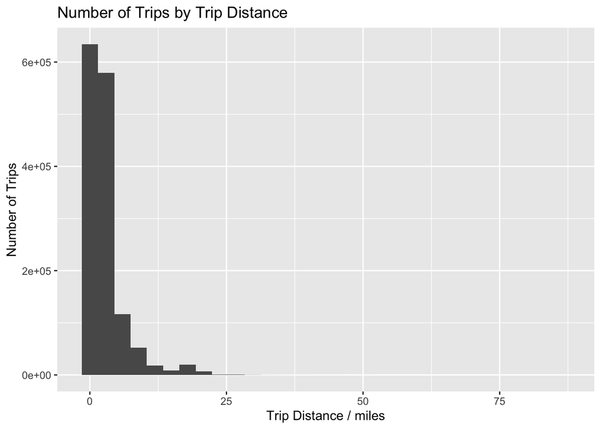

```r
taxi_train = filter(taxi_train, trip_distance > 0.2)
taxi_test = filter(taxi_test, trip_distance > 0.2)

taxi_train %>% ggplot(aes(x=trip_distance)) + geom_histogram() + labs(title = "Number of Trips by Trip Distance", x = "Trip Distance / miles", y = "Number of Trips")
```

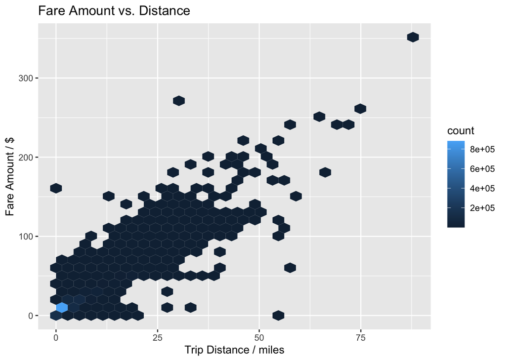

```r
taxi_train %>% ggplot(aes(x=trip_distance, y=fare_amount)) + geom_hex() + labs(title = "Fare Amount vs. Distance", x = "Trip Distance / miles", y = "Fare Amount / $")
```

Similar to `trip_duration`, some of longest trips don't match its fare amount. Based on fare rate, trips over 30 miles must be charged at least $1.00 (heavily relaxed from $2.50/m to account for traffic) per mile.

Trips more expensive than $40 also must have been charged at most $4 per mile (also relaxed, in real situation taxis can't charge more than $2.5 per mile.).

```r
# Filter
taxi_train <- taxi_train %>%
    filter(trip_distance < 30 | fare_amount > trip_distance) %>%
    filter(fare_amount < 40 | fare_amount < 4 * trip_distance + 2.5)

taxi_test <- taxi_test %>%
    filter(trip_distance < 30 | fare_amount > trip_distance) %>%
    filter(fare_amount < 40 | fare_amount < 4 * trip_distance + 2.5)
```

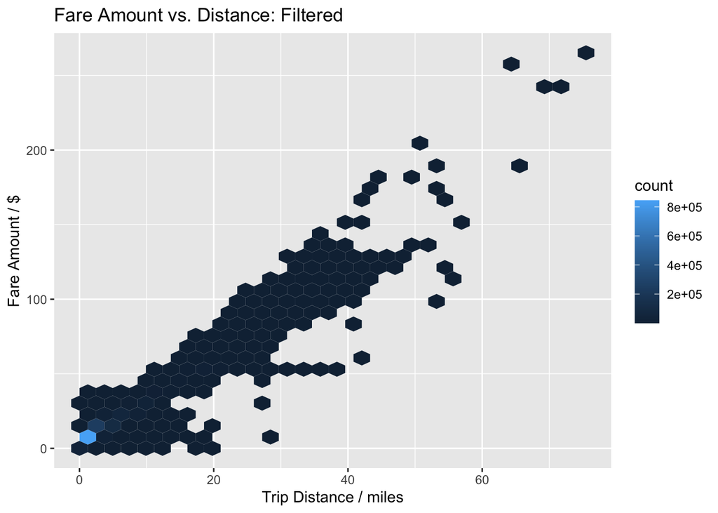

```r
taxi_train %>% ggplot(aes(x=trip_distance, y=fare_amount)) + geom_hex() + labs(title = "Fare Amount vs. Distance: Filtered", x = "Trip Distance / miles", y = "Fare Amount / $")
```

## Passenger Count

```r
# Number of trips by passenger count
taxi_train %>% group_by(passenger_count) %>%
    summarise(Frequency = n())
```

```
## # A tibble: 7 x 2
##   passenger_count Frequency
##             <dbl>     <int>
## 1               0        14
## 2               1   1035408
## 3               2    194625
## 4               3     53034
## 5               4     23419
## 6               5     80115
## 7               6     49526
```

Valid number of passengers seem to be between 1 ~ 6.

NYC's taxi website states...

- "The maximum amount of passengers allowed in a yellow taxicab by law is four (4) in a four (4) passenger taxicab or five (5) passengers in a five (5) passenger taxicab, except that an additional passenger must be accepted if such passenger is under the age of seven (7) and is held on the lap of an adult passenger seated in the rear."

https://www1.nyc.gov/site/tlc/passengers/passenger-frequently-asked-questions.page#:~:text=The%20maximum%20amount%20of%20passengers,of%20an%20adult%20passenger%20seated

Filtering out the data...

```r
taxi_train <- taxi_train %>%
    filter(passenger_count > 0 & passenger_count <= 6)
taxi_test <- taxi_test %>%
    filter(passenger_count > 0 & passenger_count <= 6)
```

## Pickup/Dropoff co-ordinates

First, make a sample to fit maps quickly.

```r
library(leaflet)
taxi_sample = sample_n(taxi_train, 1000)

leaflet(taxi_sample) %>%
    addTiles %>%
    addCircleMarkers(~pickup_longitude,~pickup_latitude, radius=2,stroke = FALSE, opacity=1, fillOpacity =1)
```

[interactive chart not shown]

There are trips with wrong co-ordinates in the data, and they will be filtered out.

```r
# pickup coordinates
pickup_min_lat <- 40.494
pickup_max_lat <- 40.918
pickup_min_long <- -74.256
pickup_max_long <- -73.700

# dropoff coordinates - wider than pickup region
dropoff_min_lat <- 39.142
dropoff_max_lat <- 41.926
dropoff_min_long <- -76.318
dropoff_max_long <- -71.272

taxi_sample <- taxi_sample %>%
    filter(pickup_longitude > pickup_min_long,
           pickup_longitude < pickup_max_long,
           pickup_latitude > pickup_min_lat,
           pickup_latitude < pickup_max_lat,
           dropoff_longitude > dropoff_min_long,
           dropoff_longitude < dropoff_max_long,
           dropoff_latitude > dropoff_min_lat,
           dropoff_latitude < dropoff_max_lat)

# try plotting again with filtered set

## pickup
leaflet(taxi_sample) %>%
  addTiles() %>%
  addCircleMarkers(~pickup_longitude,~pickup_latitude, radius=2,stroke = FALSE, opacity=1, fillOpacity =1)
```

[interactive chart not shown]

```r
## dropoff
leaflet(taxi_sample) %>%
  addTiles() %>%
  addCircleMarkers(~dropoff_longitude,~dropoff_latitude, radius=2,stroke = FALSE, opacity=1, fillOpacity =1)
```

[interactive chart not shown]

```r
# Filter
taxi_train <- taxi_train %>%
    filter(pickup_longitude > pickup_min_long,
           pickup_longitude < pickup_max_long,
           pickup_latitude > pickup_min_lat,
           pickup_latitude < pickup_max_lat,
           dropoff_longitude > dropoff_min_long,
           dropoff_longitude < dropoff_max_long,
           dropoff_latitude > dropoff_min_lat,
           dropoff_latitude < dropoff_max_lat) %>%
    select(-c(pickup_longitude, pickup_latitude, dropoff_longitude, dropoff_latitude))

taxi_test <- taxi_test %>%
    filter(pickup_longitude > pickup_min_long,
           pickup_longitude < pickup_max_long,
           pickup_latitude > pickup_min_lat,
           pickup_latitude < pickup_max_lat,
           dropoff_longitude > dropoff_min_long,
           dropoff_longitude < dropoff_max_long,
           dropoff_latitude > dropoff_min_lat,
           dropoff_latitude < dropoff_max_lat) %>%
    select(-c(pickup_longitude, pickup_latitude, dropoff_longitude, dropoff_latitude))
```

## store_and_fwd_flag

```r
# quantile
taxi_train %>% group_by(store_and_fwd_flag) %>% summarise(quantile(tip_amount)) %>%
    bind_cols("quantile" = quantile)
```

```
## # A tibble: 10 x 3
## # Groups:   store_and_fwd_flag [2]
##    store_and_fwd_flag `quantile(tip_amount)` quantile
##    <chr>                               <dbl> <chr>
##  1 N                                    0    0%
##  2 N                                    1.25 25%
##  3 N                                    1.85 50%
##  4 N                                    2.86 75%
##  5 N                                  254.   100%
##  6 Y                                    0    0%
##  7 Y                                    1.35 25%
##  8 Y                                    2    50%
##  9 Y                                    3.75 75%
## 10 Y                                   21.6  100%
```

```r
# Number of trips
taxi_train %>% group_by(store_and_fwd_flag) %>% summarise(n())
```

```
## # A tibble: 2 x 2
##   store_and_fwd_flag   `n()`
##   <chr>                <int>
## 1 N                  1408876
## 2 Y                     6645
```

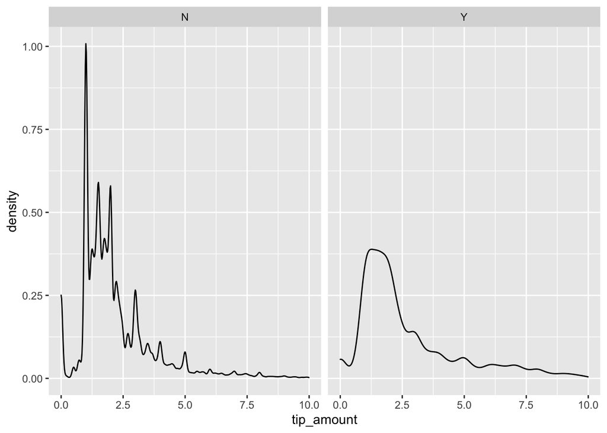

```r
# Distribution
taxi_train %>% filter(tip_amount < 10) %>% ggplot(aes(x=tip_amount)) + geom_density() + facet_wrap(store_and_fwd_flag ~ .)
```

Similar inner quantiles and distribution given large difference in group size: no anomalies here. Whether a trip had connection to the network shouldn't have any effect to the tip amount. This variable don't seem useful for our use.

```r
taxi_train <- taxi_train %>%
    select(-store_and_fwd_flag)
taxi_test <- taxi_test %>%
    select(-store_and_fwd_flag)
```

## extra

```r
# Number of trips
taxi_train %>%
    group_by(extra) %>%
    summarise(n())
```

```
## # A tibble: 6 x 2
##   extra  `n()`
##   <dbl>  <int>
## 1  0    714911
## 2  0.02      2
## 3  0.5  465310
## 4  1    235289
## 5  1.5       8
## 6  2         1
```

We know that extras can only be charged either by $0.50 or $1 and not both. $1.00 rush hour charge is in effect during 4pm - 8pm, and $0.50 overnight surcharge is in effect during 8pm - 6am. We'll also factor the 3 available amounts.

```r
taxi_train <- taxi_train %>%
    filter(extra == 0 | extra == 0.5 | extra == 1) %>%
    mutate(extra = factor(extra, ordered = FALSE))

taxi_test <- taxi_test %>%
    filter(extra == 0 | extra == 0.5 | extra == 1) %>%
    mutate(extra = factor(extra, ordered = FALSE))
```

## mta_tax

```r
# Number of trips
taxi_train %>%
    group_by(mta_tax) %>%
    summarise(nrow = n())
```

```
## # A tibble: 2 x 2
##   mta_tax    nrow
##     <dbl>   <int>
## 1     0      2596
## 2     0.5 1412914
```

MTA State Surcharge is for all trips that end in New York City or Nassau, Suffolk, Westchester, Rockland, Dutchess, Orange or Putnam Counties. It is not surprising that over 99% of our trips are charged with mta tax. This variable will be removed.

```r
taxi_train <- taxi_train %>%
    select(-mta_tax)
taxi_test <- taxi_test %>%
    select(-mta_tax)
```

## tolls_amount

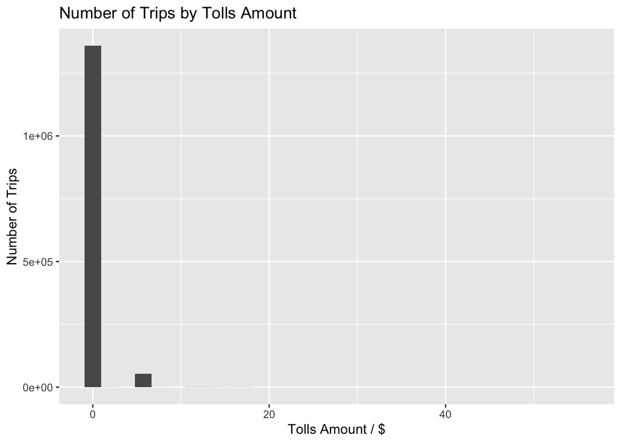

```r
taxi_train %>%
    ggplot(aes(x=tolls_amount)) +
    geom_histogram() + labs(title = "Number of Trips by Tolls Amount", x="Tolls Amount / $", y="Number of Trips")
```

```r
# Number of Trips with high tolls amount
taxi_train %>% filter(tolls_amount > 30) %>% nrow()
```

```
## [1] 8
```

```r
# Trips with high tolls amount
taxi_train %>% filter(tolls_amount > 30) %>% select(trip_duration, trip_distance, tolls_amount, fare_amount, tip_amount, total_amount)
```

```
## # A tibble: 8 x 6
##   trip_duration trip_distance tolls_amount fare_amount tip_amount total_amount
##           <dbl>         <dbl>        <dbl>       <dbl>      <dbl>        <dbl>
## 1          36.3          17.3         47.3        68         29.2        146.
## 2          46.6          20.6         30.5        76.5        0          107.
## 3          58.3          36.3         35         115          0          150.
## 4          26.0           8.6         55.3        28.5        0           85.1
## 5          53.2          13.7         30.5        47.5       15.8         94.6
## 6          95.0          40.5         30.5       120         20          171.
## 7          59.9          38.5         34.1       118          1          153.
## 8          31.7          14.0         38.7        41          0           81
```

There are some trips with high tolls amount. But nothing special.

## improvement_surcharge

```r
# Number of Trips
taxi_train %>%
    group_by(improvement_surcharge) %>%
    summarise(n())
```

```
## # A tibble: 2 x 2
##   improvement_surcharge   `n()`
##                   <dbl>   <int>
## 1                   0        14
## 2                   0.3 1415496
```

Pretty much all of the trips have improvement surcharge. This variable won't be useful.

```r
# Deleting variable
taxi_train <- taxi_train %>% select(-improvement_surcharge)
taxi_test <- taxi_test %>% select(-improvement_surcharge)
```

## tip_amount

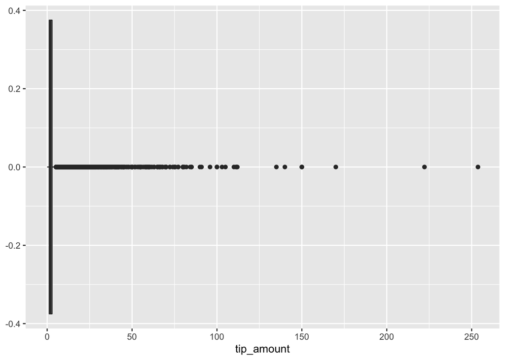

```r
# tip amount distribution
taxi_train %>% ggplot(aes(x=tip_amount)) + geom_boxplot()
```

There are many outliers.

```r
# quantile
quantile(taxi_train$tip_amount)
```

```
##     0%    25%    50%    75%   100%
##   0.00   1.25   1.85   2.86 253.73
```

```r
# Highest tip amounts
taxi_train %>%
    select(trip_distance, trip_duration, tolls_amount, total_amount, fare_amount, tip_amount) %>%
    arrange(desc(tip_amount))
```

```
## # A tibble: 1,415,510 x 6
##    trip_distance trip_duration tolls_amount total_amount fare_amount tip_amount
##            <dbl>         <dbl>        <dbl>        <dbl>       <dbl>      <dbl>
##  1          3.07          12.4         0            267.        12         254.
##  2          4.66          14.6         0            239.        15.5       222.
##  3          8.15          19.2         0            196.        25         170
##  4          7.36          38           0            178.        26.5       150
##  5         11.9           21.2         0            185.        33.5       150
##  6         41.1           49           0            240.       100         140
##  7          2.39          14.7         0            147.        11.5       135
##  8          1.75          12           0            122.         9.5       112
##  9         22.6           50.4         5.54         170.        52         112.
## 10         16.1           25.9         0            156         43.5       111.
## # … with 1,415,500 more rows
```

Most tips are between $1 ~ $3. Max quantile indiciates presence of very distant outliers. Tip amount don't seem to have direct relationship with fare amount.

# Model Fitting

Removing unnecessary variables, and adding `log1p(tip_amount)` because

1. tip amount can't be negative
2. there are lots of trips with $0 tips: standard `log` will generate `-Inf` values.

Since most monetary variables have small values, they will be converted to cents to help the model fitting process. Doing this will also make the varaible to be affected by +1 bias caused by `log1p`. transformation.

```r
taxi_train <- taxi_train %>%
    mutate(tip_amount = tip_amount * 100, # dollar to cents
           tolls_amount = tolls_amount * 100,
           fare_amount = fare_amount * 100) %>%
    mutate(log_tip_amount = log1p(tip_amount)) %>% # log transformation
    select(-c(dropoff_datetime, pickup_datetime, total_amount, tip_amount))

taxi_test <- taxi_test %>%
    mutate(tip_amount = tip_amount * 100,
           tolls_amount = tolls_amount * 100,
           fare_amount = fare_amount * 100) %>%
    mutate(log_tip_amount = log1p(tip_amount)) %>%
    select(-c(dropoff_datetime, pickup_datetime, total_amount, tip_amount))

colnames(taxi_train)
```

```
##  [1] "passenger_count"  "trip_distance"    "extra"            "dow"
##  [5] "trip_duration"    "trip_4_6_am"      "tolls_amount"     "fare_amount"
##  [9] "RatecodeID_label" "log_tip_amount"
```

```r
colnames(taxi_test)
```

```
##  [1] "passenger_count"  "trip_distance"    "extra"            "dow"
##  [5] "trip_duration"    "trip_4_6_am"      "tolls_amount"     "fare_amount"
##  [9] "RatecodeID_label" "log_tip_amount"
```

cross-validate

```r
allyhat<-function(xtrain, ytrain, xtest,lambdas,nvmax=50){
  n<-nrow(xtrain)
  yhat<-matrix(nrow=nrow(xtest),ncol=length(lambdas))
  search<-regsubsets(xtrain,ytrain, nvmax=nvmax, method="back")
  summ<-summary(search)
  for(i in 1:length(lambdas)){
    penMSE<- n*log(summ$rss)+lambdas[i]*(1:nvmax)
    best<-which.min(penMSE)  #lowest AIC
    betahat<-coef(search, best) #coefficients
    xinmodel<-cbind(1,xtest)[,summ$which[best,]] #predictors in that model
    yhat[,i]<-xinmodel%*%betahat
  }
  yhat
}
```

Linear

```r
set.seed(1)
mf_linear <- model.frame(log_tip_amount ~ ., data = taxi_train)
X_linear <- model.matrix(log_tip_amount ~ ., mf_linear)
X_linear <- X_linear[,-1]
y = taxi_train$log_tip_amount

n<-nrow(X_linear)
folds<-sample(rep(1:10,length.out=n))
lambdas <- c(1,5,10,50,100,150,200,1000, 10000, 10000000, 100000000000000000000000) # Note the values
fitted<-matrix(nrow=n,ncol=length(lambdas))
for(k in 1:10){
  train <- (1:n)[folds!=k]
  test <-(1:n)[folds==k]
  fitted[test,]<-allyhat(X_linear[train,],y[train],X_linear[test,],lambdas,nvmax = 18)
}
lmbadas_MSPE_linear = colMeans((y-fitted)^2)
lmbadas_MSPE_linear
```

```
##  [1] 1.164695 1.164695 1.164735 1.164723 1.164723 1.164844 1.164994 1.168266
##  [9] 1.177299 1.177299 1.177299
```

Lambda value does not have much effect on MSPE. Selecting labmda = 5...

```r
set.seed(2)
# test MSPE
search = regsubsets(X_linear, y, nvmax = 18, method = "backward")
summ = summary(search)
aic = n*log(summ$rss)+5*(1:18)
best = which.min(aic)
betahat = coef(search, best)
#coefficients
exp(betahat)[-1]
```

```
##                    passenger_count                      trip_distance
##                          0.9899922                          0.9930688
##                           extra0.5                             extra1
##                          1.0413268                          1.0721855
##                             dowTue                             dowWed
##                          1.0189710                          1.0136009
##                             dowThu                             dowFri
##                          1.0127819                          0.9794222
##                             dowSat                             dowSun
##                          0.9598583                          0.9602881
##                      trip_duration                     trip_4_6_amYes
##                          1.0139743                          0.8385477
##                       tolls_amount                        fare_amount
##                          1.0007604                          1.0003574
##                RatecodeID_labelJFK             RatecodeID_labelNewark
##                          0.7911596                          0.1954896
## RatecodeID_labelNassau_Westchester    RatecodeID_labelNeogitated_Fare
##                          0.3959687                          0.1357661
```

```r
test_mf = model.frame(log_tip_amount ~ ., data = taxi_test)
X_test_linear = model.matrix(log_tip_amount ~ ., data = test_mf)
X_test_linear = X_test_linear[,-1]
y_test = taxi_test$log_tip_amount

Xpred = cbind(1, X_test_linear)[,summ$which[best,]]
fitted = Xpred%*%betahat

linear_MSPE = mean((exp(y_test) - exp(fitted))^2) # exp() needed for back-transformation to cents
linear_MSPE
```

```
## [1] 680605.1
```

The model predicts with an average absolute error of `sqrt(680605.1)` = 824c = 8.24$ per trip. This is a big error considering how average tip amount is about $2.5

The model uses all the variables given, and the most affecting variable in the model is the RatecodeID. Standard rate trips (base of the model) are likely to receive more tips than all other rated trips. Their minimum percentage difference is 21% (1 - 0.79,JFK) and maximum is 86% (1 - 0.14, Negotiated_Fare). Day of the week did not have much effect as all of percentage differences between monday and other days are within 5%. More extra charges meant more tip_amount, but not by much. Surprisingly, trips that started between 4 ~ 6 am were expected to earn less tips in this model which is opposite to earlier analysis's prediction. All other variables such as passenger count and trip distance have negligible effect on the tip amount.

As to why there's such a big error, the model could not predict whether a trip received zero tips, and the squared error of those trips probably inflated the overall MSPE.

```r
colnames(fitted) = "prediction"
cbind(y_test, fitted) %>% as.tibble() %>% filter(y_test == 0)
```

```
## # A tibble: 41,442 x 2
##    y_test prediction
##     <dbl>      <dbl>
##  1      0       5.58
##  2      0       5.10
##  3      0       4.90
##  4      0       5.65
##  5      0       4.98
##  6      0       4.84
##  7      0       5.16
##  8      0       6.42
##  9      0       7.05
## 10      0       4.71
## # … with 41,432 more rows
```

Trips with non-zero trips have predicted reasonably well.

```r
cbind(y_test, fitted) %>% as.tibble() %>% filter(y_test != 0)
```

```
## # A tibble: 1,041,257 x 2
##    y_test prediction
##     <dbl>      <dbl>
##  1   5.06       4.90
##  2   5.71       5.34
##  3   5.30       5.14
##  4   5.87       5.35
##  5   5.56       4.96
##  6   4.57       4.72
##  7   5.30       5.20
##  8   5.59       5.18
##  9   6.17       5.55
## 10   5.46       5.12
## # … with 1,041,247 more rows
```

## Interaction

```r
set.seed(3)
mf_interx <- model.frame(log_tip_amount ~ .^2, data = taxi_train)
X_interx <- model.matrix(log_tip_amount ~ .^2, mf_interx)
X_interx <- X_interx[,-1]
y = taxi_train$log_tip_amount

n<-nrow(X_interx)
folds<-sample(rep(1:10,length.out=n))
lambdas <- c(1, 5,50,200, 10000000, 100000000000000000000000)
fitted<-matrix(nrow=n,ncol=length(lambdas))
for(k in 1:10){
  train <- (1:n)[folds!=k]
  test <-(1:n)[folds==k]
  fitted[test,]<-allyhat(X_interx[train,],y[train],X_interx[test,],lambdas,nvmax = 40)
}
```

```
## Reordering variables and trying again:
## Reordering variables and trying again:
## Reordering variables and trying again:
## Reordering variables and trying again:
## Reordering variables and trying again:
## Reordering variables and trying again:
## Reordering variables and trying again:
## Reordering variables and trying again:
## Reordering variables and trying again:
## Reordering variables and trying again:
```

```r
lmbadas_MSPE_interx = colMeans((y-fitted)^2)
lmbadas_MSPE_interx
```

```
## [1] 1.7731e+06 1.7731e+06 1.7731e+06 1.7731e+06 1.7731e+06 1.1773e+00
```

Interactions don't seem to help finding a good model. Lambda value must be ridiculasily large in order to find the model with an acceptable MSPE.

```r
set.seed(4)
# test MSPE
search = regsubsets(X_interx, y, nvmax = 40, method = "backward")
```

```
## Reordering variables and trying again:
```

```r
summ = summary(search)
aic = n*log(summ$rss)+100000000000000000000000*(1:40)
best = which.min(aic)
betahat = coef(search, best)
betahat
```

```
##  (Intercept)  fare_amount
## 4.5521918383 0.0004712462
```

```r
X_test_mf = model.frame(log_tip_amount ~ .^2, data = taxi_test)
X_test_interx = model.matrix(log_tip_amount ~.^2, data = X_test_mf)
X_test_interx = X_test_interx[,-1]


Xpred = cbind(1, X_test_interx)[,summ$which[best,]]
fitted = Xpred%*%betahat

interx_MSPE = mean((exp(y_test) - exp(fitted))^2) # exp() needed for back-transformation to real-cents
interx_MSPE
```

```
## [1] 4644844
```

Given how most variables were proven to be ineffective in the linear model, it's no surprise that `regsubsets` had difficulty finding a good model. The best model chosen with ridiculously large lambda includes only one varaible: fare amount. The average error is `sqrt(4644844)` = 2155c = 21.55$ which is a lot worse than the linear model.

## Lasso

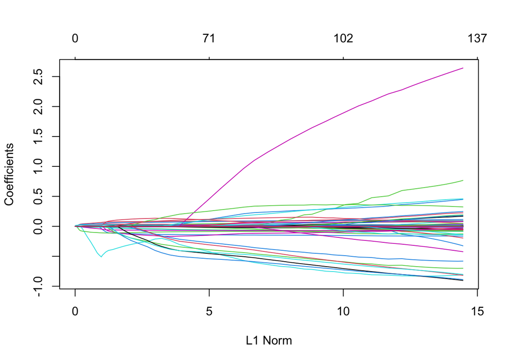

```r
set.seed(5)
lasso_taxi = glmnet(X_interx, y)
lasso_taxi_cv = cv.glmnet(X_interx, y)

plot(lasso_taxi)
```

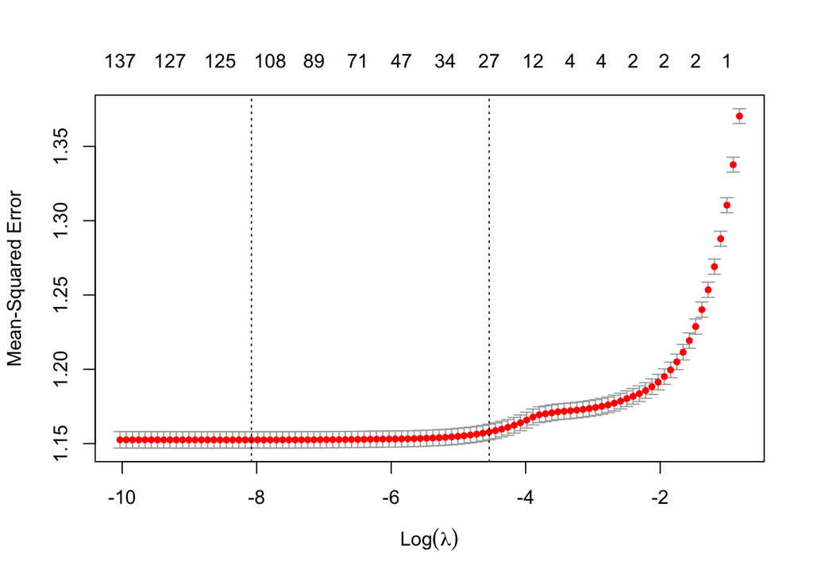

```r
plot(lasso_taxi_cv)
```

```r
interx_lasso_pred = predict(lasso_taxi, X_test_interx, s = lasso_taxi_cv$lambda.min)
coef(lasso_taxi, s=lasso_taxi_cv$lambda.min)
```

```
## 150 x 1 sparse Matrix of class "dgCMatrix"
##                                                                1
## (Intercept)                                         4.417193e+00
## passenger_count                                    -6.415979e-03
## trip_distance                                       9.518457e-02
## extra0.5                                            6.937171e-02
## extra1                                              1.042848e-01
## dowTue                                              2.437357e-03
## dowWed                                             -5.977476e-05
## dowThu                                              .
## dowFri                                              .
## dowSat                                              .
## dowSun                                              .
## trip_duration                                       2.674968e-02
## trip_4_6_amYes                                      .
## tolls_amount                                        5.992171e-04
## fare_amount                                         1.828753e-04
## RatecodeID_labelJFK                                 7.927643e-02
## RatecodeID_labelNewark                              4.978417e-01
## RatecodeID_labelNassau_Westchester                 -4.876157e-02
## RatecodeID_labelNeogitated_Fare                    -8.122751e-01
## passenger_count:trip_distance                       .
## passenger_count:extra0.5                           -3.183752e-03
## passenger_count:extra1                             -7.357827e-06
## passenger_count:dowTue                              1.160121e-03
## passenger_count:dowWed                             -3.301547e-03
## passenger_count:dowThu                             -3.400039e-03
## passenger_count:dowFri                              .
## passenger_count:dowSat                              .
## passenger_count:dowSun                             -3.388696e-04
## passenger_count:trip_duration                      -1.461368e-04
## passenger_count:trip_4_6_amYes                     -6.580135e-03
## passenger_count:tolls_amount                        .
## passenger_count:fare_amount                         .
## passenger_count:RatecodeID_labelJFK                 2.240830e-02
## passenger_count:RatecodeID_labelNewark             -4.726553e-02
## passenger_count:RatecodeID_labelNassau_Westchester -1.264388e-01
## passenger_count:RatecodeID_labelNeogitated_Fare    -1.598118e-01
## trip_distance:extra0.5                             -1.047901e-02
## trip_distance:extra1                                .
```

[output cut: 97 more lines]

```
## trip_4_6_amYes:tolls_amount                         2.852194e-04
## trip_4_6_amYes:fare_amount                          3.873668e-07
## trip_4_6_amYes:RatecodeID_labelJFK                  1.046434e-01
## trip_4_6_amYes:RatecodeID_labelNewark               5.848279e-03
## trip_4_6_amYes:RatecodeID_labelNassau_Westchester   8.586659e-02
## trip_4_6_amYes:RatecodeID_labelNeogitated_Fare     -3.559560e-02
## tolls_amount:fare_amount                            .
## tolls_amount:RatecodeID_labelJFK                   -9.512235e-05
## tolls_amount:RatecodeID_labelNewark                -8.981829e-04
## tolls_amount:RatecodeID_labelNassau_Westchester    -1.744536e-04
## tolls_amount:RatecodeID_labelNeogitated_Fare       -9.543951e-04
## fare_amount:RatecodeID_labelJFK                     3.151888e-07
## fare_amount:RatecodeID_labelNewark                  .
## fare_amount:RatecodeID_labelNassau_Westchester      5.483470e-07
## fare_amount:RatecodeID_labelNeogitated_Fare         1.841979e-04
```

```r
# MSPE
mean((exp(y_test) - exp(interx_lasso_pred))^2)
```

```
## [1] 34692.02
```

## Ridge

```r
set.seed(6)
ridge_taxi = glmnet(X_interx, y, alpha = 0)
ridge_taxi_cv = cv.glmnet(X_interx, y, alpha = 0)
```

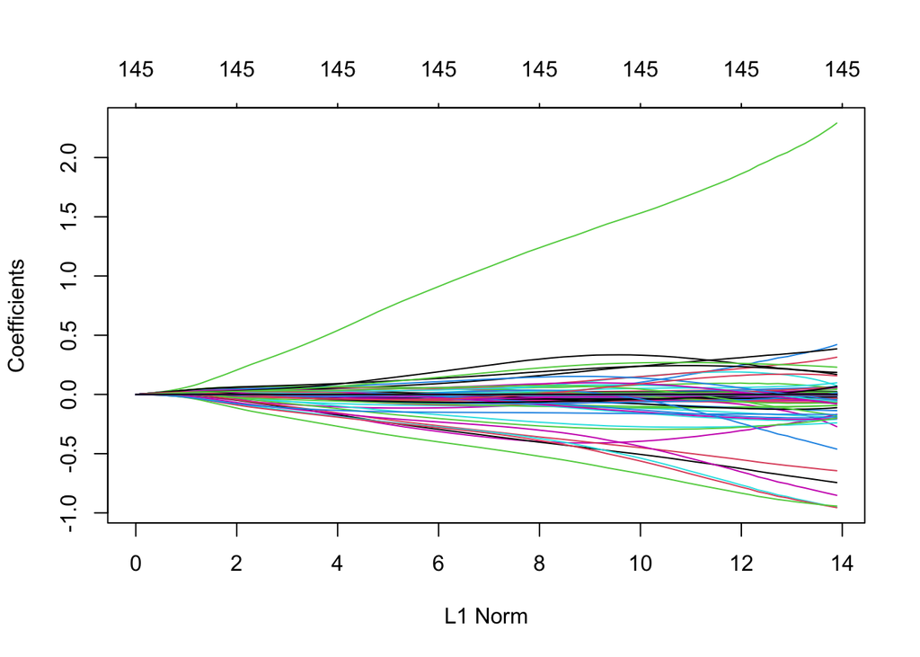

```r
plot(ridge_taxi)
```

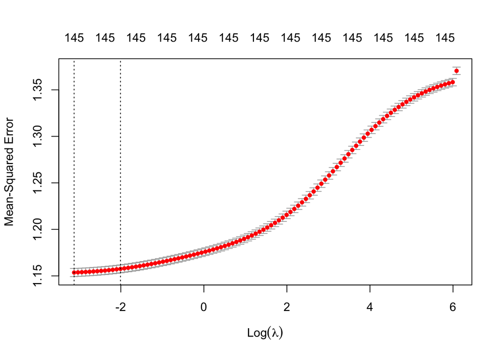

```r
plot(ridge_taxi_cv)
```

```r
coef(ridge_taxi, s=ridge_taxi_cv$lambda.min)
```

```
## 150 x 1 sparse Matrix of class "dgCMatrix"
##                                                                1
## (Intercept)                                         4.510094e+00
## passenger_count                                    -9.325222e-03
## trip_distance                                       5.509178e-02
## extra0.5                                            4.295611e-02
## extra1                                              6.719695e-02
## dowTue                                             -3.215950e-02
## dowWed                                             -3.903917e-02
## dowThu                                             -3.206960e-02
## dowFri                                             -3.418059e-02
## dowSat                                             -3.545995e-02
## dowSun                                             -3.885296e-02
## trip_duration                                       2.195732e-02
## trip_4_6_amYes                                     -1.228337e-02
## tolls_amount                                        7.222029e-04
## fare_amount                                         2.014532e-04
## RatecodeID_labelJFK                                 4.860810e-02
## RatecodeID_labelNewark                              4.208357e-01
## RatecodeID_labelNassau_Westchester                  7.360927e-02
## RatecodeID_labelNeogitated_Fare                    -2.719028e-01
## passenger_count:trip_distance                       6.046212e-04
## passenger_count:extra0.5                           -3.505736e-03
## passenger_count:extra1                              8.763140e-07
## passenger_count:dowTue                             -4.733051e-03
## passenger_count:dowWed                             -9.485919e-03
## passenger_count:dowThu                             -9.985908e-03
## passenger_count:dowFri                             -5.977748e-03
## passenger_count:dowSat                             -5.926917e-03
## passenger_count:dowSun                             -7.030027e-03
## passenger_count:trip_duration                       7.998731e-05
## passenger_count:trip_4_6_amYes                     -8.980445e-03
## passenger_count:tolls_amount                        5.425754e-06
## passenger_count:fare_amount                         3.919574e-06
## passenger_count:RatecodeID_labelJFK                -9.842595e-03
## passenger_count:RatecodeID_labelNewark             -9.205717e-02
## passenger_count:RatecodeID_labelNassau_Westchester -1.364855e-01
## passenger_count:RatecodeID_labelNeogitated_Fare    -1.911117e-01
## trip_distance:extra0.5                             -4.796502e-03
## trip_distance:extra1                                1.058365e-03
```

[output cut: 97 more lines]

```
## trip_4_6_amYes:tolls_amount                         2.469197e-04
## trip_4_6_amYes:fare_amount                          1.069000e-05
## trip_4_6_amYes:RatecodeID_labelJFK                  1.683873e-01
## trip_4_6_amYes:RatecodeID_labelNewark               1.569594e-01
## trip_4_6_amYes:RatecodeID_labelNassau_Westchester   2.299978e-01
## trip_4_6_amYes:RatecodeID_labelNeogitated_Fare     -1.704339e-01
## tolls_amount:fare_amount                            1.428787e-08
## tolls_amount:RatecodeID_labelJFK                    3.189407e-06
## tolls_amount:RatecodeID_labelNewark                -6.482235e-04
## tolls_amount:RatecodeID_labelNassau_Westchester    -2.785280e-04
## tolls_amount:RatecodeID_labelNeogitated_Fare       -8.019833e-04
## fare_amount:RatecodeID_labelJFK                     3.222339e-05
## fare_amount:RatecodeID_labelNewark                  1.190799e-05
## fare_amount:RatecodeID_labelNassau_Westchester     -3.040441e-06
## fare_amount:RatecodeID_labelNeogitated_Fare         7.926381e-05
```

```r
interx_ridge_pred = predict(ridge_taxi, X_test_interx, s = ridge_taxi_cv$lambda.min)
coef(ridge_taxi, s=ridge_taxi_cv$lambda.min)
```

```
## 150 x 1 sparse Matrix of class "dgCMatrix"
##                                                                1
## (Intercept)                                         4.510094e+00
## passenger_count                                    -9.325222e-03
## trip_distance                                       5.509178e-02
## extra0.5                                            4.295611e-02
## extra1                                              6.719695e-02
## dowTue                                             -3.215950e-02
## dowWed                                             -3.903917e-02
## dowThu                                             -3.206960e-02
## dowFri                                             -3.418059e-02
## dowSat                                             -3.545995e-02
## dowSun                                             -3.885296e-02
## trip_duration                                       2.195732e-02
## trip_4_6_amYes                                     -1.228337e-02
## tolls_amount                                        7.222029e-04
## fare_amount                                         2.014532e-04
## RatecodeID_labelJFK                                 4.860810e-02
## RatecodeID_labelNewark                              4.208357e-01
## RatecodeID_labelNassau_Westchester                  7.360927e-02
## RatecodeID_labelNeogitated_Fare                    -2.719028e-01
## passenger_count:trip_distance                       6.046212e-04
## passenger_count:extra0.5                           -3.505736e-03
## passenger_count:extra1                              8.763140e-07
## passenger_count:dowTue                             -4.733051e-03
## passenger_count:dowWed                             -9.485919e-03
## passenger_count:dowThu                             -9.985908e-03
## passenger_count:dowFri                             -5.977748e-03
## passenger_count:dowSat                             -5.926917e-03
## passenger_count:dowSun                             -7.030027e-03
## passenger_count:trip_duration                       7.998731e-05
## passenger_count:trip_4_6_amYes                     -8.980445e-03
## passenger_count:tolls_amount                        5.425754e-06
## passenger_count:fare_amount                         3.919574e-06
## passenger_count:RatecodeID_labelJFK                -9.842595e-03
## passenger_count:RatecodeID_labelNewark             -9.205717e-02
## passenger_count:RatecodeID_labelNassau_Westchester -1.364855e-01
## passenger_count:RatecodeID_labelNeogitated_Fare    -1.911117e-01
## trip_distance:extra0.5                             -4.796502e-03
## trip_distance:extra1                                1.058365e-03
```

[output cut: 97 more lines]

```
## trip_4_6_amYes:tolls_amount                         2.469197e-04
## trip_4_6_amYes:fare_amount                          1.069000e-05
## trip_4_6_amYes:RatecodeID_labelJFK                  1.683873e-01
## trip_4_6_amYes:RatecodeID_labelNewark               1.569594e-01
## trip_4_6_amYes:RatecodeID_labelNassau_Westchester   2.299978e-01
## trip_4_6_amYes:RatecodeID_labelNeogitated_Fare     -1.704339e-01
## tolls_amount:fare_amount                            1.428787e-08
## tolls_amount:RatecodeID_labelJFK                    3.189407e-06
## tolls_amount:RatecodeID_labelNewark                -6.482235e-04
## tolls_amount:RatecodeID_labelNassau_Westchester    -2.785280e-04
## tolls_amount:RatecodeID_labelNeogitated_Fare       -8.019833e-04
## fare_amount:RatecodeID_labelJFK                     3.222339e-05
## fare_amount:RatecodeID_labelNewark                  1.190799e-05
## fare_amount:RatecodeID_labelNassau_Westchester     -3.040441e-06
## fare_amount:RatecodeID_labelNeogitated_Fare         7.926381e-05
```

```r
# MSPE
mean((exp(y_test) - exp(interx_ridge_pred))^2)
```

```
## [1] 36511.65
```

Ridge regression predicts slightly worse than lasso, with average `sqrt(36511.65)` = 191c = 1.91$. Possible reason for this might be that ridge model is using more variables than lasso model, and we know from standard linear/interaction models that a lot of these variables are not particularily useful.

# Conclusion

All of the models I've built are not reliable for accurate prediction. Linear model proved that most variables left after the cleaning process weren't particularily useful, therefore interaction model also did not perform well. Lasso and Ridge regression both performed much better than the standard linear/interaction models, bringing the mean prediction error from ~$8 to ~$2, however, this error is still very large. I suspect the general reason for the bad performance is the variables' incapability of catching the arbitrarity of the outliers. There are many big outlier-passengers who tipped a lot, and it is unlikely that it had anything to do with the trip information. Understandable reasons for hefty tips might include the kindness of the driver or the passenger's mood of the day, and these are not instilled in the dataset.

*p.s. factoring all the trip start hours (which I couldn't with my gear) may have resulted in better performance, but I doubt it.*